# Adult Census Income Prediction

The goal here is to predict wether a person has an income of more than 50k or not. This is basically a binary classification problem where a person's salary is classified into the two groups

> 50K group or <=50K group.

Source :

https://www.kaggle.com/uciml/adult-census-income

This data was extracted from the 1994 Census bureau database by Ronny Kohavi and Barry Becker (Data Mining and Visualization, Silicon Graphics). The prediction task is to predict whether income exceeds $50k per year based on the provided. census data provided above. The Datasets consists of a list of records , each of which explains various features of a person along with his income per year.

A brief description of the features are as follows: Attributes: income (Target Variable): >50K, <=50K Predictors :-

age: continuous workclass: Private, Self-emp-not-inc, Self-emp-inc, Federal-gov, Local-gov, State-gov, Without-pay, Never-worked fnlwgt: continuous education: Bachelors, Some-college, 11th, HS-grad, Prof-school, Assoc-acdm, Assoc-voc, 9th, 7th-8th, 12th, Masters, 1st-4th, 10th, Doctorate, 5th-6th, Preschool education-num: continuous marital-status: Married-civ-spouse, Divorced, Never-married, Separated, Widowed, Married-spouse-absent, Married-AF-spouse occupation: Tech-support, Craft-repair, Other-service, Sales, Exec-managerial, Prof-specialty, Handlers-cleaners, Machine-op-inspct, Adm-clerical, Farming-fishing, Transport-moving, Priv-house-serv, Protective-serv, Armed-Forces relationship: Wife, Own-child, Husband, Not-in-family, Other-relative, Unmarried race: White, Asian-Pac-Islander, Amer-Indian-Eskimo, Other, Black sex: Female, Male capital-gain: continuous capital-loss: continuous hours-per-week: continuous native-country: United-States, Cambodia, England, Puerto-Rico, Canada, Germany, Outlying-US(Guam-USVI-etc), India, Japan, Greece, South, China, Cuba, Iran, Honduras, Philippines, Italy, Poland, Jamaica, Vietnam, Mexico, Portugal, Ireland, France, Dominican-Republic, Laos, Ecuador, Taiwan, Haiti, Columbia, Hungary, Guatemala, Nicaragua, Scotland, Thailand, Yugoslavia, El-Salvador, Trinadad&Tobago, Peru, Hong, Holand-Netherlands

```python
# importing libraries

import pandas as pd
import seaborn as sns
import numpy as np
from numpy import nan
import missingno as msno
import matplotlib.pyplot as plt
from collections import Counter
from sklearn.preprocessing import StandardScaler
from sklearn.model_selection import train_test_split
from sklearn.linear_model import LogisticRegression
from sklearn import metrics
from sklearn.metrics import accuracy_score
from sklearn.ensemble import RandomForestClassifier
from sklearn.dummy import DummyClassifier
from sklearn.naive_bayes import CategoricalNB
from sklearn.naive_bayes import GaussianNB
from sklearn.neighbors import KNeighborsClassifier
from sklearn import svm
from sklearn.tree import DecisionTreeClassifier
```

```python
df = pd.read_csv("/Users/sujithasunkara/Documents/Kaggle/Income prediction/adult.csv")
df.head()
```

|  | age | workclass | fnlwgt | education | education-num | marital-status | occupation | relationship | race | sex | capital-gain | capital-loss | hours-per-week | country | salary |
| --- | --- | --- | --- | --- | --- | --- | --- | --- | --- | --- | --- | --- | --- | --- | --- |
| 0 | 39 | State-gov | 77516 | Bachelors | 13 | Never-married | Adm-clerical | Not-in-family | White | Male | 2174 | 0 | 40 | United-States | <=50K |
| 1 | 50 | Self-emp-not-inc | 83311 | Bachelors | 13 | Married-civ-spouse | Exec-managerial | Husband | White | Male | 0 | 0 | 13 | United-States | <=50K |
| 2 | 38 | Private | 215646 | HS-grad | 9 | Divorced | Handlers-cleaners | Not-in-family | White | Male | 0 | 0 | 40 | United-States | <=50K |
| 3 | 53 | Private | 234721 | 11th | 7 | Married-civ-spouse | Handlers-cleaners | Husband | Black | Male | 0 | 0 | 40 | United-States | <=50K |
| 4 | 28 | Private | 338409 | Bachelors | 13 | Married-civ-spouse | Prof-specialty | Wife | Black | Female | 0 | 0 | 40 | Cuba | <=50K |

```python
df.info()
```

```
<class 'pandas.core.frame.DataFrame'>
RangeIndex: 32561 entries, 0 to 32560
Data columns (total 15 columns):
 #   Column          Non-Null Count  Dtype
---  ------          --------------  -----
 0   age             32561 non-null  int64
 1   workclass       32561 non-null  object
 2   fnlwgt          32561 non-null  int64
 3   education       32561 non-null  object
 4   education-num   32561 non-null  int64
 5   marital-status  32561 non-null  object
 6   occupation      32561 non-null  object
 7   relationship    32561 non-null  object
 8   race            32561 non-null  object
 9   sex             32561 non-null  object
 10  capital-gain    32561 non-null  int64
 11  capital-loss    32561 non-null  int64
 12  hours-per-week  32561 non-null  int64
 13  country         32561 non-null  object
 14  salary          32561 non-null  object
dtypes: int64(6), object(9)
memory usage: 3.7+ MB
```

```python
# Checking unique values for all variables
df['workclass'].unique()
```

```
array([' State-gov', ' Self-emp-not-inc', ' Private', ' Federal-gov',
       ' Local-gov', ' ?', ' Self-emp-inc', ' Without-pay',
       ' Never-worked'], dtype=object)
```

```python
df['fnlwgt'].unique()
df['education'].unique()
df['education-num'].unique()
df['marital-status'].unique()
df['occupation'].unique()
```

```
array([' Adm-clerical', ' Exec-managerial', ' Handlers-cleaners',
       ' Prof-specialty', ' Other-service', ' Sales', ' Craft-repair',
       ' Transport-moving', ' Farming-fishing', ' Machine-op-inspct',
       ' Tech-support', ' ?', ' Protective-serv', ' Armed-Forces',
       ' Priv-house-serv'], dtype=object)
```

```python
df['relationship'].unique()
df['race'].unique()
df['sex'].unique()
df['country'].unique()
```

```
array([' United-States', ' Cuba', ' Jamaica', ' India', ' ?', ' Mexico',
       ' South', ' Puerto-Rico', ' Honduras', ' England', ' Canada',
       ' Germany', ' Iran', ' Philippines', ' Italy', ' Poland',
       ' Columbia', ' Cambodia', ' Thailand', ' Ecuador', ' Laos',
       ' Taiwan', ' Haiti', ' Portugal', ' Dominican-Republic',
       ' El-Salvador', ' France', ' Guatemala', ' China', ' Japan',
       ' Yugoslavia', ' Peru', ' Outlying-US(Guam-USVI-etc)', ' Scotland',
       ' Trinadad&Tobago', ' Greece', ' Nicaragua', ' Vietnam', ' Hong',
       ' Ireland', ' Hungary', ' Holand-Netherlands'], dtype=object)
```

Here we have noticed that there is a special character in workspace and in occupation. so we are replacing those values with nan.

```python
df =df.replace(' ?',nan)
```

```python
# Checking for null values
df.isnull().sum()
```

```
age                  0
workclass         1836
fnlwgt               0
education            0
education-num        0
marital-status       0
occupation        1843
relationship         0
race                 0
sex                  0
capital-gain         0
capital-loss         0
hours-per-week       0
country            583
salary               0
dtype: int64
```

```python
type(df.workclass)
```

```
pandas.core.series.Series
```

```python
df.describe()
```

|  | age | fnlwgt | education-num | capital-gain | capital-loss | hours-per-week |
| --- | --- | --- | --- | --- | --- | --- |
| count | 32561.000000 | 3.256100e+04 | 32561.000000 | 32561.000000 | 32561.000000 | 32561.000000 |
| mean | 38.581647 | 1.897784e+05 | 10.080679 | 1077.648844 | 87.303830 | 40.437456 |
| std | 13.640433 | 1.055500e+05 | 2.572720 | 7385.292085 | 402.960219 | 12.347429 |
| min | 17.000000 | 1.228500e+04 | 1.000000 | 0.000000 | 0.000000 | 1.000000 |
| 25% | 28.000000 | 1.178270e+05 | 9.000000 | 0.000000 | 0.000000 | 40.000000 |
| 50% | 37.000000 | 1.783560e+05 | 10.000000 | 0.000000 | 0.000000 | 40.000000 |
| 75% | 48.000000 | 2.370510e+05 | 12.000000 | 0.000000 | 0.000000 | 45.000000 |
| max | 90.000000 | 1.484705e+06 | 16.000000 | 99999.000000 | 4356.000000 | 99.000000 |

```python
df.shape
```

```
(32561, 15)
```

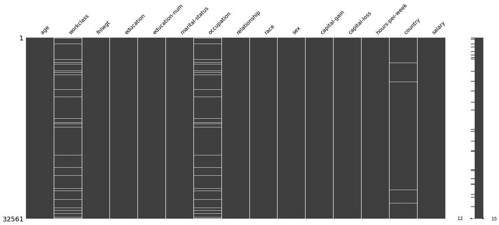

```python
msno.matrix(df)
```

we can notice from graph as workplace, occupation and country has missing values. We have large datadet with more than 32500 values and missed data is around 1800. so we will drop the values.

```python
df= df.dropna()
```

```python
df.head()
```

|  | age | workclass | fnlwgt | education | education-num | marital-status | occupation | relationship | race | sex | capital-gain | capital-loss | hours-per-week | country | salary |
| --- | --- | --- | --- | --- | --- | --- | --- | --- | --- | --- | --- | --- | --- | --- | --- |
| 0 | 39 | State-gov | 77516 | Bachelors | 13 | Never-married | Adm-clerical | Not-in-family | White | Male | 2174 | 0 | 40 | United-States | <=50K |
| 1 | 50 | Self-emp-not-inc | 83311 | Bachelors | 13 | Married-civ-spouse | Exec-managerial | Husband | White | Male | 0 | 0 | 13 | United-States | <=50K |
| 2 | 38 | Private | 215646 | HS-grad | 9 | Divorced | Handlers-cleaners | Not-in-family | White | Male | 0 | 0 | 40 | United-States | <=50K |
| 3 | 53 | Private | 234721 | 11th | 7 | Married-civ-spouse | Handlers-cleaners | Husband | Black | Male | 0 | 0 | 40 | United-States | <=50K |
| 4 | 28 | Private | 338409 | Bachelors | 13 | Married-civ-spouse | Prof-specialty | Wife | Black | Female | 0 | 0 | 40 | Cuba | <=50K |

```python
#EDA
#converting Salary to a numeric variable
df['salary'].value_counts()
```

```
 <=50K    22654
 >50K      7508
Name: salary, dtype: int64
```

```python
counter = Counter(df['salary'])
for k,v in counter.items():
    per = v / len(df['salary']) * 100
    print('Class=%s, Count=%d, Percentage=%.3f%%' % (k, v, per))
```

```
Class= <=50K, Count=22654, Percentage=75.108%
Class= >50K, Count=7508, Percentage=24.892%
```

```
 <=50K    22654
 >50K      7508
Name: salary, dtype: int64
```

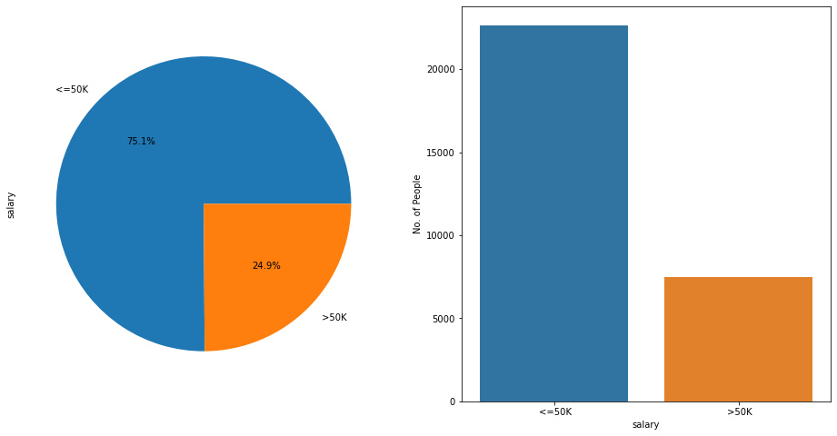

```python
plt.figure(figsize=(16,8))
plt.subplot(1,2,1)
df['salary'].value_counts().plot.pie(autopct='%1.1f%%')
plt.subplot(1,2,2)
sns.countplot(x='salary',data=df)
plt.ylabel('No. of People')
df['salary'].value_counts()
```

```python
df['salary']= df['salary'].map({' <=50K': 0,' >50K':1}).astype(int)
df.head()
```

|  | age | workclass | fnlwgt | education | education-num | marital-status | occupation | relationship | race | sex | capital-gain | capital-loss | hours-per-week | country | salary |
| --- | --- | --- | --- | --- | --- | --- | --- | --- | --- | --- | --- | --- | --- | --- | --- |
| 0 | 39 | State-gov | 77516 | Bachelors | 13 | Never-married | Adm-clerical | Not-in-family | White | Male | 2174 | 0 | 40 | United-States | 0 |
| 1 | 50 | Self-emp-not-inc | 83311 | Bachelors | 13 | Married-civ-spouse | Exec-managerial | Husband | White | Male | 0 | 0 | 13 | United-States | 0 |
| 2 | 38 | Private | 215646 | HS-grad | 9 | Divorced | Handlers-cleaners | Not-in-family | White | Male | 0 | 0 | 40 | United-States | 0 |
| 3 | 53 | Private | 234721 | 11th | 7 | Married-civ-spouse | Handlers-cleaners | Husband | Black | Male | 0 | 0 | 40 | United-States | 0 |
| 4 | 28 | Private | 338409 | Bachelors | 13 | Married-civ-spouse | Prof-specialty | Wife | Black | Female | 0 | 0 | 40 | Cuba | 0 |

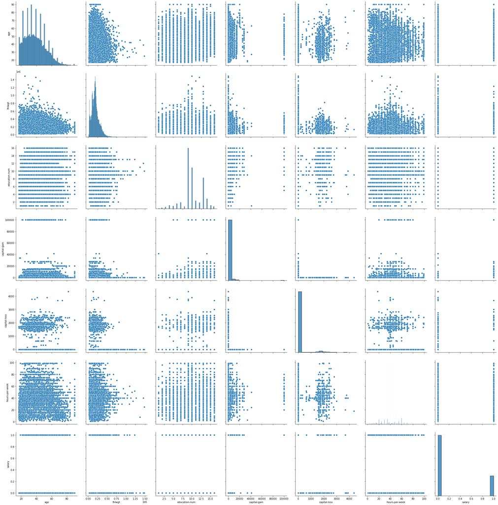

```python
#Data Visualisation
pplot = sns.pairplot(df)
pplot.fig.set_size_inches(30,30)
```

```python
def age_group(x):
    x= int(x)
    x= abs(x)
    if (x<=18):
        return "Less than 18"
    if (18<x<30):
        return "19-30"
    if (30<x<50):
        return "30-50"
    if (50<x<70 ):
        return "50-70"
    else:
        return "Greater than 70"
```

```python
df['age_group']= df['age'].apply(age_group)
df.head()
```

|  | age | workclass | fnlwgt | education | education-num | marital-status | occupation | relationship | race | sex | capital-gain | capital-loss | hours-per-week | country | salary | age_group |
| --- | --- | --- | --- | --- | --- | --- | --- | --- | --- | --- | --- | --- | --- | --- | --- | --- |
| 0 | 39 | State-gov | 77516 | Bachelors | 13 | Never-married | Adm-clerical | Not-in-family | White | Male | 2174 | 0 | 40 | United-States | 0 | 30-50 |
| 1 | 50 | Self-emp-not-inc | 83311 | Bachelors | 13 | Married-civ-spouse | Exec-managerial | Husband | White | Male | 0 | 0 | 13 | United-States | 0 | Greater than 70 |
| 2 | 38 | Private | 215646 | HS-grad | 9 | Divorced | Handlers-cleaners | Not-in-family | White | Male | 0 | 0 | 40 | United-States | 0 | 30-50 |
| 3 | 53 | Private | 234721 | 11th | 7 | Married-civ-spouse | Handlers-cleaners | Husband | Black | Male | 0 | 0 | 40 | United-States | 0 | 50-70 |
| 4 | 28 | Private | 338409 | Bachelors | 13 | Married-civ-spouse | Prof-specialty | Wife | Black | Female | 0 | 0 | 40 | Cuba | 0 | 19-30 |

```python
df_category = ['workclass','education','marital-status','occupation','relationship','race','sex',"age_group"]
```

```python
## Univariate analysis
def univariate(df,col):
    plt.figure (figsize = (16,8))

    if df[col].dtype !='int64' or df[col]!='float64':
        plt.subplot(1,2,1)
        df[col].value_counts().plot.pie(autopct='%1.1f%%')
        plt.subplot(1,2,2)
        sns.countplot(x= col,data=df)
        plt.xlabel(col)
        plt.ylabel('No. of People')
        plt.xticks(rotation =90)

    plt.show()
```

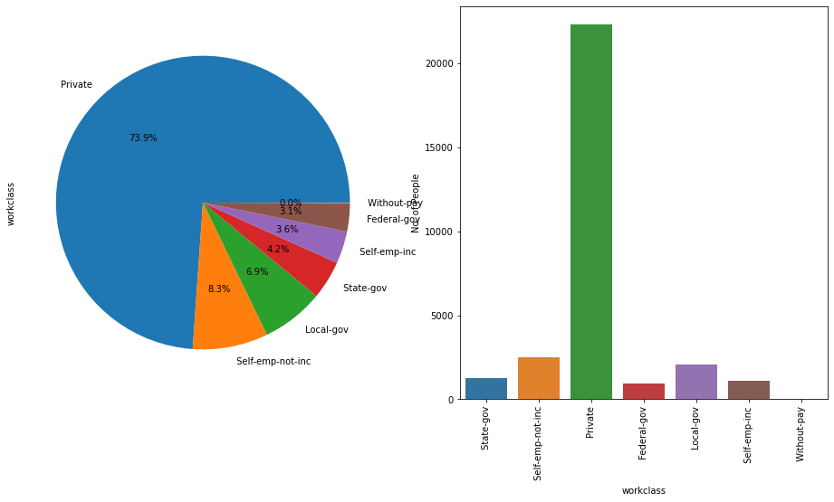

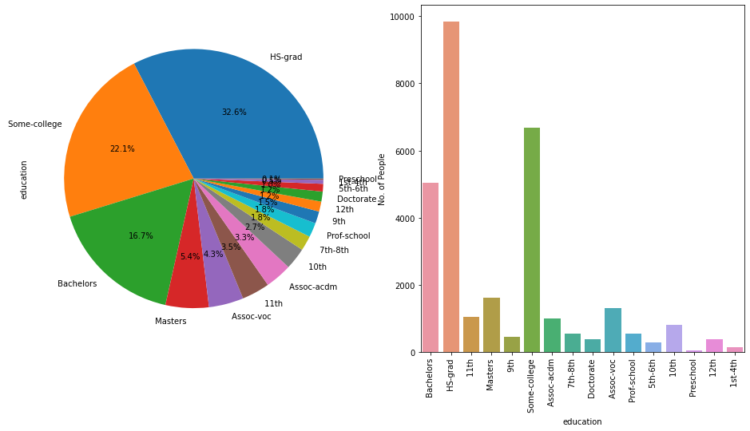

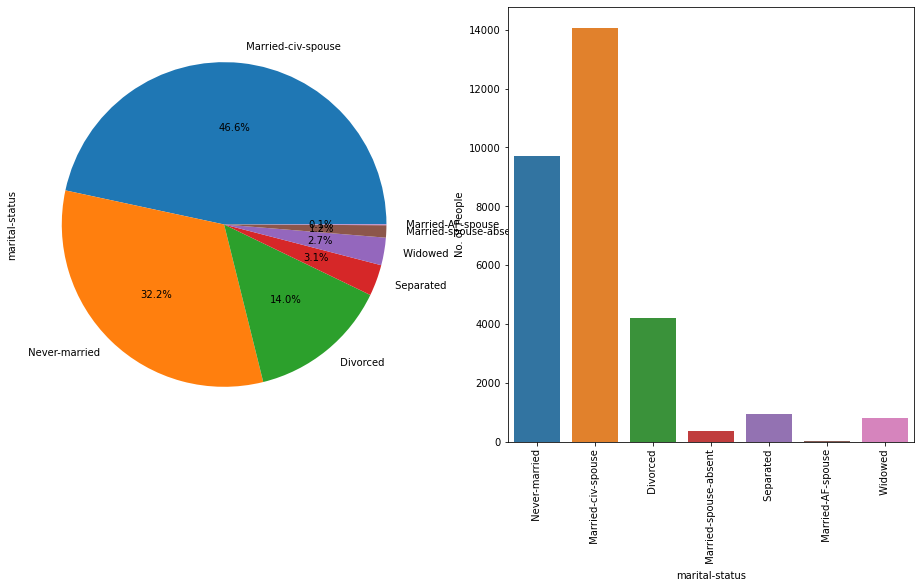

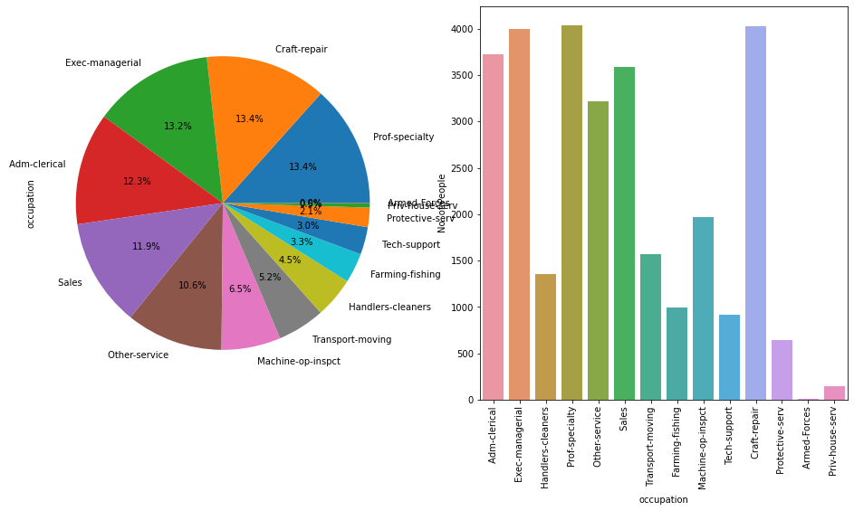

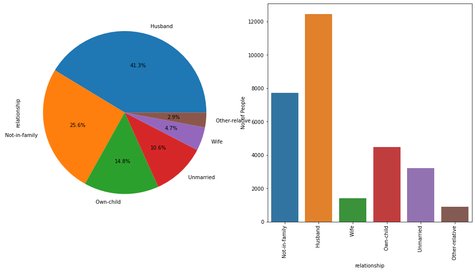

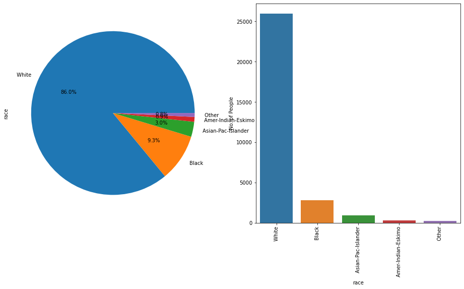

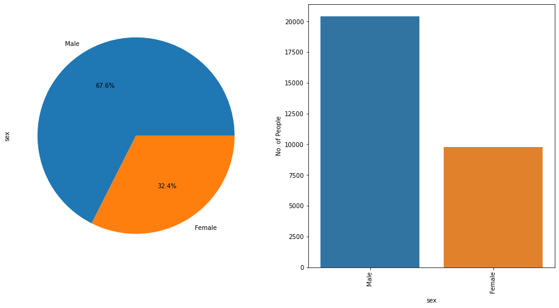

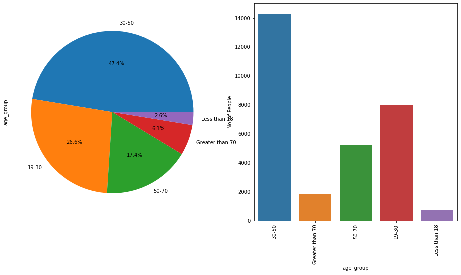

```python
for features in df_category:
    univariate(df,features)
```

```python
def salary_mean(df,col1,col2):
    x = df[[col1,col2]].groupby([col1]).mean()
    return x
```

```python
for features in df_category:
    print(salary_mean(df,features,'salary'))
```

```
                     salary
workclass
 Federal-gov       0.387063
 Local-gov         0.294630
 Private           0.218792
 Self-emp-inc      0.558659
 Self-emp-not-inc  0.285714
 State-gov         0.268960
 Without-pay       0.000000
                 salary
education
 10th          0.071951
 11th          0.056298
 12th          0.076923
 1st-4th       0.039735
 5th-6th       0.041667
 7th-8th       0.062837
 9th           0.054945
 Assoc-acdm    0.253968
 Assoc-voc     0.263198
 Bachelors     0.421491
 Doctorate     0.746667
 HS-grad       0.164329
 Masters       0.564229
 Preschool     0.000000
 Prof-school   0.749077
 Some-college  0.200060
                          salary
marital-status
 Divorced               0.107262
 Married-AF-spouse      0.476190
 Married-civ-spouse     0.454959
 Married-spouse-absent  0.083784
 Never-married          0.048324
 Separated              0.070288
 Widowed                0.096735
                      salary
occupation
 Adm-clerical       0.133835
 Armed-Forces       0.111111
```

[output cut: 23 more lines]

```
 Asian-Pac-Islander  0.277095
 Black               0.129925
 Other               0.090909
 White               0.263718
           salary
sex
 Female  0.113678
 Male    0.313837
                   salary
age_group
19-30            0.061681
30-50            0.326409
50-70            0.350496
Greater than 70  0.277233
Less than 18     0.000000
```

```python
##barplot
def plot_fetures(df, col):
    plt.figure (figsize = (16,8))


    if df[col].dtype !='int64' or df[col]=='salary':
        plt.subplot(1,2,1)
        col_mean = df.groupby(col)['salary'].mean()
        col_mean.sort_values().plot(kind='bar')
        plt.xlabel(col)
        plt.ylabel("salary")
        plt.title("Salary prediction")

        plt.subplot(1,2,2)
        sns.countplot(x=col, hue= 'salary', data = df)

        plt.xticks(rotation =90)

    plt.show()
```

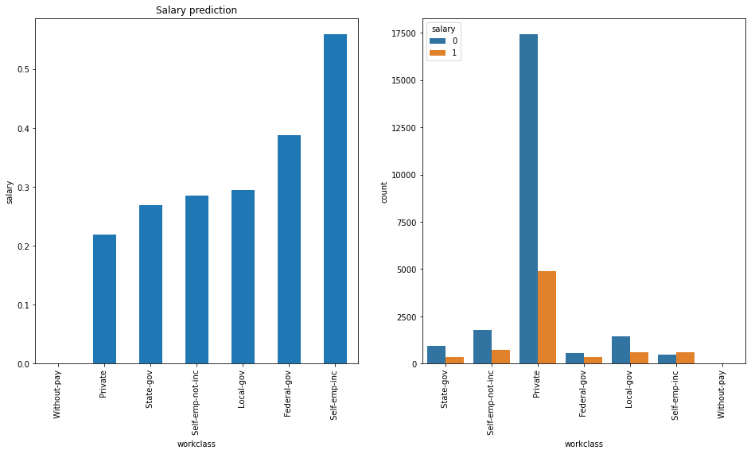

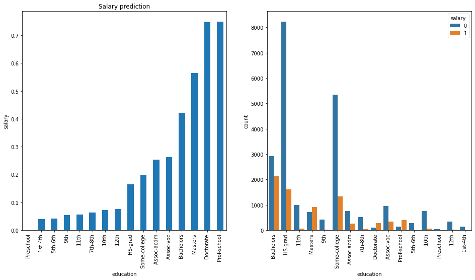

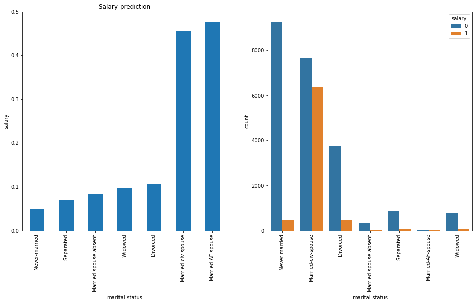

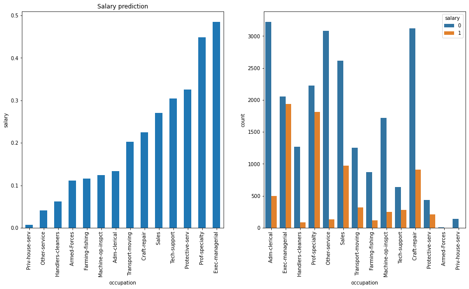

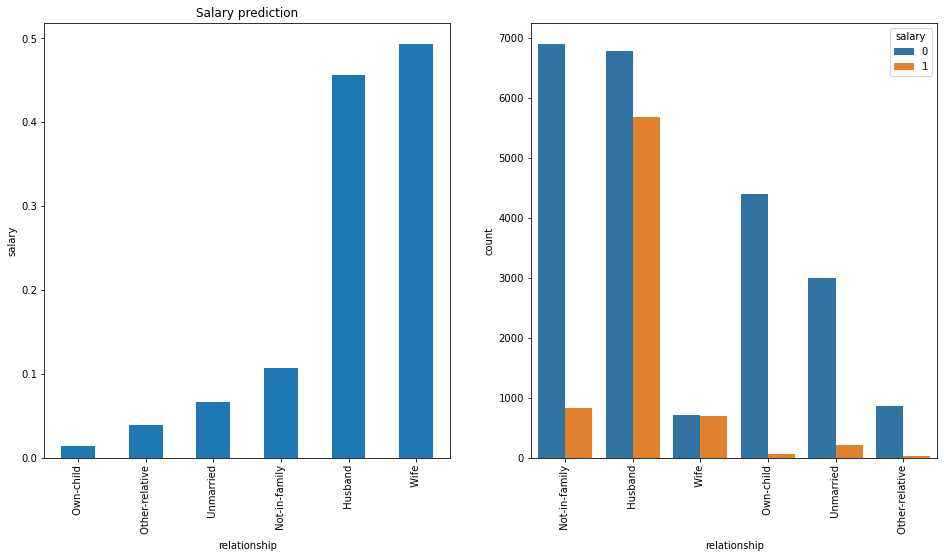

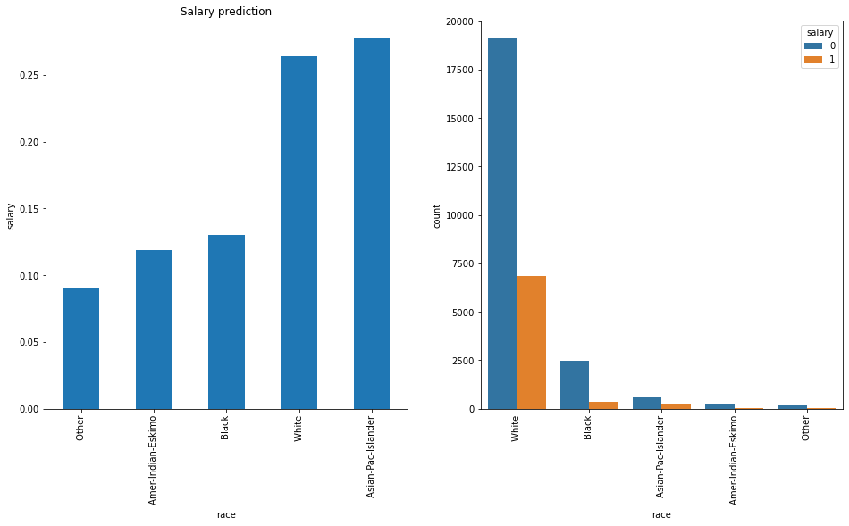

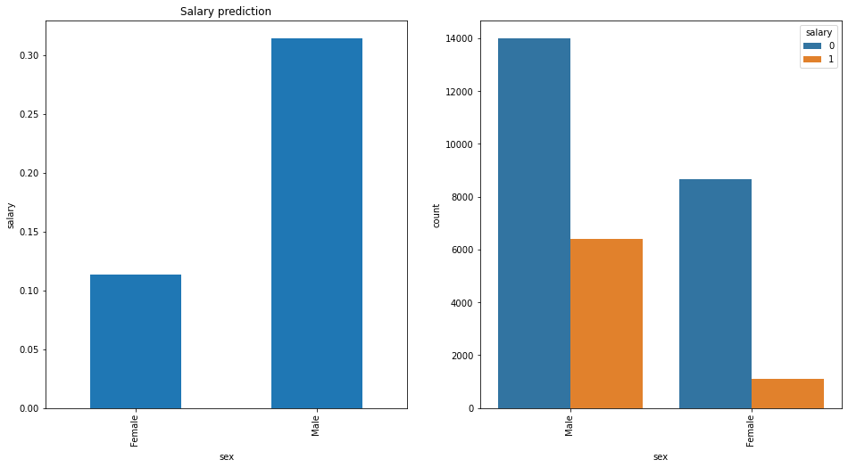

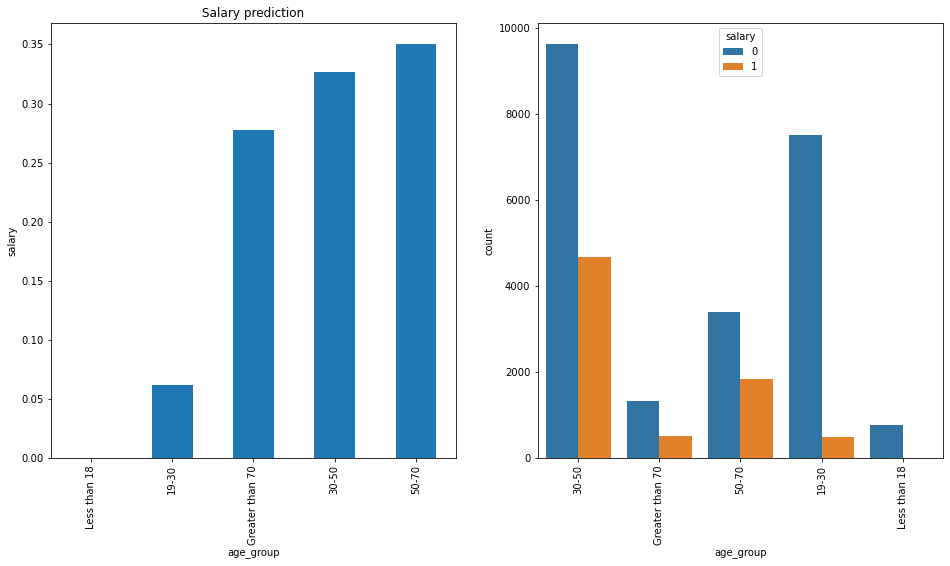

```python
for features in df_category:
    plot_fetures(df,features)
```

```python
df_numerical = ['age','fnlwgt','education-num','capital-gain', 'capital-loss', 'hours-per-week']
type(df.age)
```

```
pandas.core.series.Series
```

```python
def plots(df,col):
    plt.figure(figsize=(10,5))
    plt.subplot(1,2,1)
    if df[col].dtype == 'int64' or df[col].dtype == 'float64':

        sns.distplot(df[col])
        plt.subplot(1,2,2)
        sns.boxplot(x='salary', y = col, data =df )
    plt.show()
```

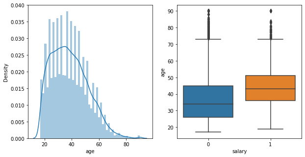

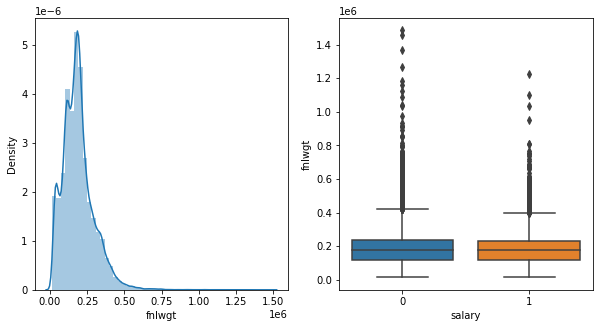

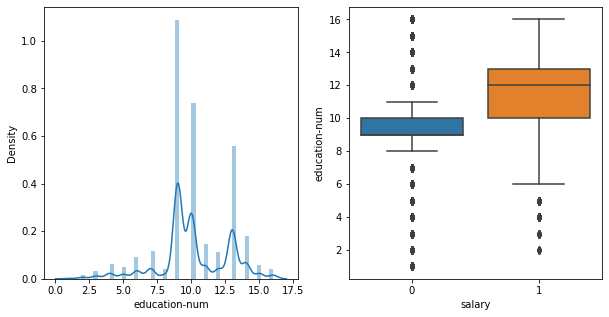

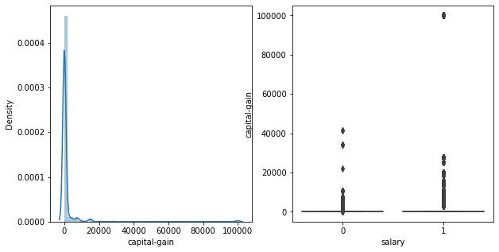

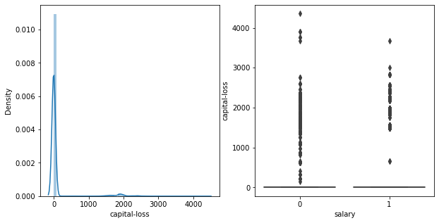

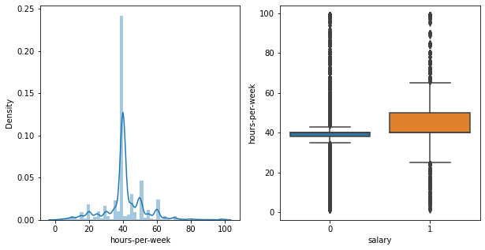

```python
for features in df_numerical:
    plots(df,features)
```

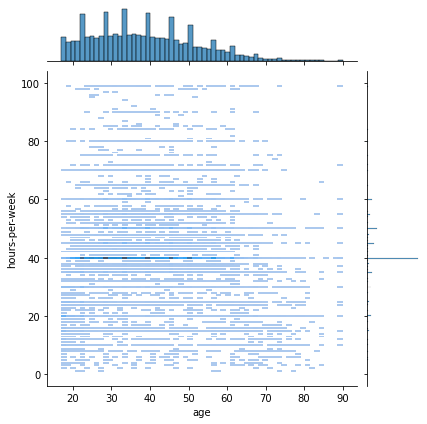

```python
# Hours per week and Age
sns.jointplot(x ="age", y = 'hours-per-week', data = df , kind = 'hist' )
```

All ages people worked mostly around 40 hours per week

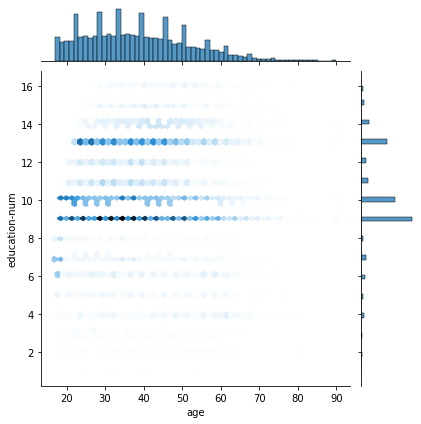

```python
sns.jointplot(x ='age', y = 'education-num', data = df , kind = "hex")
```

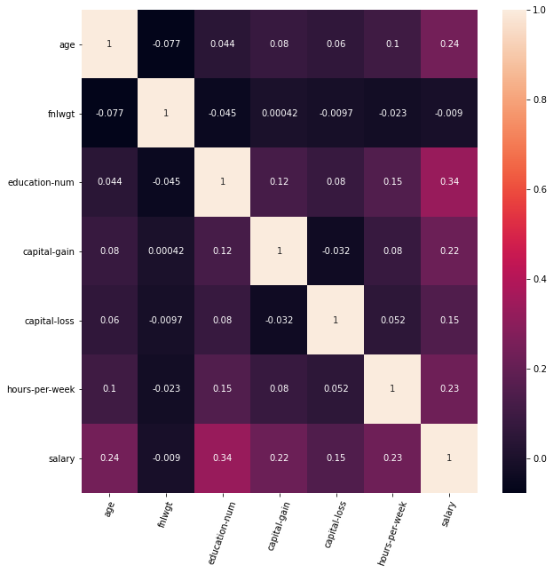

```python
##Correlation between variables
corr_matrix = df.corr()
plt.figure(figsize =(10,10))
sns.heatmap(corr_matrix, annot = True)
plt.xticks(rotation =70)
plt.yticks(rotation =0)
plt.show()
```

other than fnlwgt all other variables have positive correltion

```python
## converting all categorical variables into numerical variables
```

```python
def f(x):
    if x['workclass'] == ' Federal-gov' or x['workclass']== ' Local-gov' or x['workclass']==' State-gov': return 'govt'
    elif x['workclass'] == ' Private':return 'private'
    elif x['workclass'] == ' Self-emp-inc' or x['workclass'] == ' Self-emp-not-inc': return 'self_employed'
    else: return 'without_pay'


df['employment_type']=df.apply(f, axis=1)
df['employment_type']= df['employment_type'].map({'without_pay':0,'self_employed':1,'private':2,'govt':3}).astype(int)
```

```python
df['relationship'] = df['relationship'].map({' Unmarried':0,' Wife':1,' Husband':2,' Not-in-family':3,' Own-child':4,
                                            ' Other-relative':5}).astype(int)
df['marital-status'] = df['marital-status'].replace([' Divorced',' Married-spouse-absent',' Never-married',' Separated',' Widowed'],'Single')
df['marital-status'] = df['marital-status'].replace([' Married-AF-spouse',' Married-civ-spouse'],'Couple')
```

```python
df[['marital-status','relationship','salary']].groupby(['marital-status','relationship']).mean()
```

| marital-status | relationship | salary |
| --- | --- | --- |
| Couple | 1 | 0.493599 |
|  | 2 | 0.455669 |
|  | 3 | 0.285714 |
|  | 4 | 0.178571 |
|  | 5 | 0.142857 |
| Single | 0 | 0.066314 |
|  | 3 | 0.106198 |
|  | 4 | 0.011182 |
|  | 5 | 0.023377 |

```python
df['marital-status'] = df['marital-status'].map({'Single':0,'Couple':1}).astype(int)
```

```python
df['occupation'] = df['occupation'].map({' Adm-clerical':0,' Exec-managerial':1, ' Handlers-cleaners':2,
       ' Prof-specialty':3, ' Other-service':4, ' Sales':5, ' Transport-moving':6,
       ' Farming-fishing':7, ' Machine-op-inspct':8, ' Tech-support':9,
       ' Craft-repair':10, ' Protective-serv':11, ' Armed-Forces':12,
       ' Priv-house-serv':13}).astype(int)
```

```python
df['race']= df['race'].map({' White':0,' Amer-Indian-Eskimo':1,' Asian-Pac-Islander':2,' Black':3,' Other':4}).astype(int)
```

```python
df['country']= np.where(df['country']==' United-States',1,0)
```

```python
df['sex'] = np.where(df['sex']==' Male',0,1)
```

```python
df['capital-gain'] = np.where(df['capital-gain']>1,1,0)
```

```python
df['capital-loss'] = np.where(df['capital-loss']>1,1,0)
```

```python
df['age_group'].unique()
```

```
array(['30-50', 'Greater than 70', '50-70', '19-30', 'Less than 18'],
      dtype=object)
```

```python
df['age_group'] = df['age_group'].map({'Less than 18':0,'19-30':1,'30-50':2,'50-70':3,'Greater than 70':4})
```

```python
df.drop(['workclass','education','age','fnlwgt'],axis =1, inplace = True)
```

```python
df.head()
```

|  | education-num | marital-status | occupation | relationship | race | sex | capital-gain | capital-loss | hours-per-week | country | salary | age_group | employment_type |
| --- | --- | --- | --- | --- | --- | --- | --- | --- | --- | --- | --- | --- | --- |
| 0 | 13 | 0 | 0 | 3 | 0 | 0 | 1 | 0 | 40 | 1 | 0 | 2 | 3 |
| 1 | 13 | 1 | 1 | 2 | 0 | 0 | 0 | 0 | 13 | 1 | 0 | 4 | 1 |
| 2 | 9 | 0 | 2 | 3 | 0 | 0 | 0 | 0 | 40 | 1 | 0 | 2 | 2 |
| 3 | 7 | 1 | 2 | 2 | 3 | 0 | 0 | 0 | 40 | 1 | 0 | 3 | 2 |
| 4 | 13 | 1 | 3 | 1 | 3 | 1 | 0 | 0 | 40 | 0 | 0 | 1 | 2 |

```python
## Feature Scaling
feature_scale=[feature for feature in df.columns if feature not in ['salary']]

from sklearn.preprocessing import MinMaxScaler
scaler=MinMaxScaler()
scaler.fit(df[feature_scale])
```

```
MinMaxScaler()
```

```python
scaler.transform(df[feature_scale])
```

```
array([[0.8       , 0.        , 0.        , ..., 1.        , 0.5       ,
        1.        ],
       [0.8       , 1.        , 0.07692308, ..., 1.        , 1.        ,
        0.33333333],
       [0.53333333, 0.        , 0.15384615, ..., 1.        , 0.5       ,
        0.66666667],
       ...,
       [0.53333333, 0.        , 0.        , ..., 1.        , 0.75      ,
        0.66666667],
       [0.53333333, 0.        , 0.        , ..., 1.        , 0.25      ,
        0.66666667],
       [0.53333333, 1.        , 0.07692308, ..., 1.        , 0.75      ,
        0.33333333]])
```

```python
df = pd.concat([df[['salary']].reset_index(drop=True),
                    pd.DataFrame(scaler.transform(df[feature_scale]), columns=feature_scale)],
                    axis=1)
```

```python
df.head()
```

|  | salary | education-num | marital-status | occupation | relationship | race | sex | capital-gain | capital-loss | hours-per-week | country | age_group | employment_type |
| --- | --- | --- | --- | --- | --- | --- | --- | --- | --- | --- | --- | --- | --- |
| 0 | 0 | 0.800000 | 0.0 | 0.000000 | 0.6 | 0.00 | 0.0 | 1.0 | 0.0 | 0.397959 | 1.0 | 0.50 | 1.000000 |
| 1 | 0 | 0.800000 | 1.0 | 0.076923 | 0.4 | 0.00 | 0.0 | 0.0 | 0.0 | 0.122449 | 1.0 | 1.00 | 0.333333 |
| 2 | 0 | 0.533333 | 0.0 | 0.153846 | 0.6 | 0.00 | 0.0 | 0.0 | 0.0 | 0.397959 | 1.0 | 0.50 | 0.666667 |
| 3 | 0 | 0.400000 | 1.0 | 0.153846 | 0.4 | 0.75 | 0.0 | 0.0 | 0.0 | 0.397959 | 1.0 | 0.75 | 0.666667 |
| 4 | 0 | 0.800000 | 1.0 | 0.230769 | 0.2 | 0.75 | 1.0 | 0.0 | 0.0 | 0.397959 | 0.0 | 0.25 | 0.666667 |

```python
#Feature Selection
## Train_test split
X = df.drop(columns=['salary'])
y = df.salary
```

```python
x_train,x_test,y_train,y_test = train_test_split(X, y, test_size = 0.2, random_state = 42)
```

```python
y_test.shape
```

```
(6033,)
```

```python
##baseline model
import statistics
guess = statistics.mode(df['salary'])
y_pred_base = [guess]*len(y_test)
score = accuracy_score(y_test,y_pred_base)
print(f'Base line accuracy {round(score*100,0)}%')
```

```
Base line accuracy 75.0%
```

```python
# Create dummy classifer
dummy = DummyClassifier(strategy='uniform', random_state=1)

# "Train" model
dummy.fit(x_train, y_train)
# Get accuracy score
dummy.score(x_test, y_test)
```

```
0.5027349577324715
```

```python
##Model
model = LogisticRegression()
# Train model with training data
model.fit(x_train,y_train)
```

```
LogisticRegression()
```

```python
## prediction on our test data
y_pred = model.predict(x_test)
```

```python
##Accuracy
print("Accuracy: ",metrics.accuracy_score(y_test, y_pred))
```

```
Accuracy:  0.8317586606994861
```

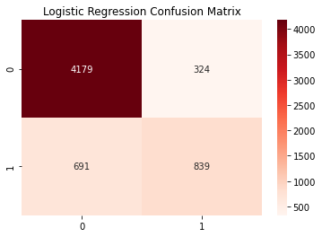

```python
from sklearn.metrics import precision_score, recall_score, confusion_matrix, classification_report,accuracy_score, f1_score
cf=confusion_matrix(y_test, y_pred)
TP=cf[1][1]
TN=cf[0][0]
FN=cf[1][0]
FP=cf[0][1]
sns.heatmap(confusion_matrix(y_test, y_pred),cmap='Reds', annot=True, fmt='d')
plt.title("Logistic Regression Confusion Matrix")
```

```python
print('Accuracy on test:', accuracy_score(y_test,y_pred),"\n")
print('F1 score on test:', f1_score(y_test,y_pred),"\n")
precision=(TP/(TP+FP))
print("Precision :" , precision,"\n")
specificity=TN/(TN+FP)
print("Specificity :" , specificity,"\n")
recall=TP/(TP+FN)
print("Recall :" , recall,"\n")
```

```
Accuracy on test: 0.8317586606994861

F1 score on test: 0.6230969179353881

Precision : 0.7214101461736887

Specificity : 0.9280479680213192

Recall : 0.5483660130718955
```

```python
# Random forest
rf = RandomForestClassifier(n_estimators = 100, random_state = 42)
```

```python
# Train model with training data
rf.fit(x_train,y_train)
```

```
RandomForestClassifier(random_state=42)
```

```python
## prediction on our test data
y_pred1 = rf.predict(x_test)
y_pred1
```

```
array([0, 0, 0, ..., 1, 0, 0])
```

```python
acc_Rforest = accuracy_score(y_test,y_pred1)
acc_Rforest
```

```
0.8251284601359191
```

```python
## Decision tree
tree = DecisionTreeClassifier(max_depth=11)
tree = tree.fit(x_train, y_train)
# PREDICTIONS
tree_predictions = tree.predict(x_test)
acc_tree = accuracy_score(y_test,tree_predictions)
acc_tree
```

```
0.8281120503895243
```

```python
#Support vector machines

svm = svm.SVC(kernel='linear')
svm = svm.fit(x_train, y_train)
```

```python
# PREDICTIONS
svm_predictions = svm.predict(x_test)
acc_suppvm = accuracy_score(y_test,svm_predictions)
acc_suppvm #
```

```
0.8319244157135753
```

```python
##KNN
knn = KNeighborsClassifier(n_neighbors=40)
knn = knn.fit(x_train, y_train)
```

```python
knn_predictions = knn.predict(x_test)
acc_knn = accuracy_score(y_test,knn_predictions)
acc_knn
```

```
0.820321564727333
```

```python
###naive bayes
### Categorical Naive bayes
cnb = CategoricalNB()
cnb = cnb.fit(x_train, y_train)

# PREDICTIONS
cnb_predictions = cnb.predict(x_test)
acc_cnb = accuracy_score(y_test,cnb_predictions)
acc_cnb # show test set score
```

```
0.7997679429802752
```